# Lab 4c. Deep Learning - iNaturalist

# Deep Learning with R / Python Exercises

You’ll first learn about Computer Vision techniques by going through the Chapter 5 lab exercises:

- 5.1 Introduction to convnets R: html, Rmd ; Python: [html](https://github.com/bbest/deep-learning-with-python-notebooks/blob/master/first_edition/5.1-introduction-to-convnets.ipynb), ipynb
- 5.2 Training a convnet from scratch on a small dataset R: html, Rmd ; Python: [html](https://github.com/bbest/deep-learning-with-python-notebooks/blob/master/first_edition/5.2-using-convnets-with-small-datasets.ipynb), ipynb

The subsequent lab exercises meet the limits of using a CPU over a GPU, which is not available on `taylor.bren.ucsb.edu`. Here’s as far as I was able to get for demonstration sake, but you’re not expected to run this. You might want to try if you have personal computer with a GPU setup.

- 5.3 Using a pretrained convnet R: html, Rmd ; Python: [html](https://github.com/bbest/deep-learning-with-python-notebooks/blob/master/first_edition/5.3-using-a-pretrained-convnet.ipynb), ipynb

# iNaturalist

The main lab that you’ll turn in is to apply these techniques to a small subset of the iNaturalist species imagery. These data were downloaded from the links provided at [github.com/visipedia/inat_comp:2021/](https://github.com/visipedia/inat_comp/tree/master/2021). Of all the 10,000 species and many images for each from training (Train), training mini (Train Mini), validation (Val) and test images, you’ll draw only from the Train Mini set of images:

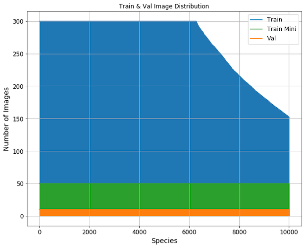

The first step is to move the images into directories for the variety of models. The `keras::`[`flow_images_from_directory()`](https://keras.rstudio.com/reference/flow_images_from_directory.html) expects the first argument `directory` to “contain one subdirectory per class”. We are building models for two species `spp2` (binary) and ten species `spp10` (multiclass), plus we want to have `train` (n=30), `validation` (n=10) and `test` (n=10) images assigned to each. So we want a directory structure that looks something like this:

```
├── spp10
│   ├── test
│   │   ├── 01172_Animalia_Arthropoda_Insecta_Lepidoptera_Geometridae_Circopetes_obtusata
│   │   │   ├── cfd17d74-c7aa-49a2-9417-0a4e6aa4170d.jpg
│   │   │   ├── d6c2cf8f-89ef-40a2-824b-f51c85be030b.jpg
│   │   │   └── ...[+n_img=8]
│   │   ├── 06033_Plantae_Tracheophyta_Liliopsida_Asparagales_Orchidaceae_Epipactis_atrorubens
│   │   │   └── ...[n_img=10]
│   │   └── ...[+n_spp=8]
│   ├── train
│   │   ├── 01172_Animalia_Arthropoda_Insecta_Lepidoptera_Geometridae_Circopetes_obtusata
│   │   │   └── ...[n_img=30]
│   │   └── ...[+n_spp=9]
│   └── validation
│       ├── 01172_Animalia_Arthropoda_Insecta_Lepidoptera_Geometridae_Circopetes_obtusata
│       │   └── ...[n_img=10]
│       └── ...[+n_spp=9]
└── spp2
    ├── test
    │   └── ...[n_spp=2]
    ├── train
    │   └── ...[n_spp=2]
    └── validation
        └── ...[n_spp=2]
```

# Move images into directories for the various models.

```r
librarian::shelf(
  digest, dplyr, DT, glue, purrr, readr, stringr, tidyr, here, keras, tensorflow)
```

[output not shown]

```r
# path to folder containing species directories of images
dir_src  <- "/courses/EDS232/inaturalist-2021/train_mini"
dir_dest <- here("inat/")
dir.create(dir_dest, showWarnings = F)

# get list of directories, one per species (n = 10,000 species)
dirs_spp <- list.dirs(dir_src, recursive = F, full.names = T)
n_spp <- length(dirs_spp)

# set seed (for reproducible results)
# just before sampling (otherwise get different results)
# based on your username (unique amongst class)
Sys.info()[["user"]] %>%
  digest::digest2int() %>%
  set.seed()
i10 <- sample(1:n_spp, 10)

# show the 10 indices sampled of the 10,000 possible
i10
```

```
##  [1] 4036  352 1448 4329 1875 4698 5879 8581 7262 3311
```

```r
# show the 10 species directory names
basename(dirs_spp)[i10]
```

```
##  [1] "04035_Animalia_Chordata_Aves_Passeriformes_Paridae_Parus_minor"
##  [2] "00351_Animalia_Arthropoda_Insecta_Coleoptera_Geotrupidae_Anoplotrupes_stercorosus"
##  [3] "01447_Animalia_Arthropoda_Insecta_Lepidoptera_Lycaenidae_Callophrys_eryphon"
##  [4] "04328_Animalia_Chordata_Aves_Passeriformes_Tyrannidae_Tyrannus_couchii"
##  [5] "01874_Animalia_Arthropoda_Insecta_Lepidoptera_Nymphalidae_Hipparchia_semele"
##  [6] "04697_Animalia_Chordata_Mammalia_Carnivora_Mustelidae_Meles_meles"
##  [7] "05878_Plantae_Tracheophyta_Liliopsida_Asparagales_Asparagaceae_Asparagus_acutifolius"
##  [8] "08580_Plantae_Tracheophyta_Magnoliopsida_Lamiales_Orobanchaceae_Castilleja_linariifolia"
##  [9] "07261_Plantae_Tracheophyta_Magnoliopsida_Brassicales_Brassicaceae_Lepidium_nitidum"
## [10] "03310_Animalia_Chordata_Aves_Caprimulgiformes_Trochilidae_Calypte_anna"
```

```r
# show the first 2 species directory names
i2 <- i10[1:2]
basename(dirs_spp)[i2]
```

```
## [1] "04035_Animalia_Chordata_Aves_Passeriformes_Paridae_Parus_minor"
## [2] "00351_Animalia_Arthropoda_Insecta_Coleoptera_Geotrupidae_Anoplotrupes_stercorosus"
```

```r
# setup data frame with source (src) and destination (dest) paths to images
d <- tibble(
  set     = c(rep("spp2", 2), rep("spp10", 10)),
  dir_sp  = c(dirs_spp[i2], dirs_spp[i10]),
  tbl_img = map(dir_sp, function(dir_sp){
    tibble(
      src_img = list.files(dir_sp, full.names = T),
      subset  = c(rep("train", 30), rep("validation", 10), rep("test", 10))) })) %>%
  unnest(tbl_img) %>%
  mutate(
    sp       = basename(dir_sp),
    img      = basename(src_img),
    dest_img = glue("{dir_dest}/{set}/{subset}/{sp}/{img}"))

# show source and destination for first 10 rows of tibble
d %>%
  select(src_img, dest_img)
```

```
## # A tibble: 600 × 2
##    src_img                                dest_img
##    <chr>                                  <glue>
##  1 /courses/EDS232/inaturalist-2021/trai… /Users/c_d_h/eds232_lab4c/inat//spp2/…
##  2 /courses/EDS232/inaturalist-2021/trai… /Users/c_d_h/eds232_lab4c/inat//spp2/…
##  3 /courses/EDS232/inaturalist-2021/trai… /Users/c_d_h/eds232_lab4c/inat//spp2/…
##  4 /courses/EDS232/inaturalist-2021/trai… /Users/c_d_h/eds232_lab4c/inat//spp2/…
##  5 /courses/EDS232/inaturalist-2021/trai… /Users/c_d_h/eds232_lab4c/inat//spp2/…
##  6 /courses/EDS232/inaturalist-2021/trai… /Users/c_d_h/eds232_lab4c/inat//spp2/…
##  7 /courses/EDS232/inaturalist-2021/trai… /Users/c_d_h/eds232_lab4c/inat//spp2/…
##  8 /courses/EDS232/inaturalist-2021/trai… /Users/c_d_h/eds232_lab4c/inat//spp2/…
##  9 /courses/EDS232/inaturalist-2021/trai… /Users/c_d_h/eds232_lab4c/inat//spp2/…
## 10 /courses/EDS232/inaturalist-2021/trai… /Users/c_d_h/eds232_lab4c/inat//spp2/…
## # … with 590 more rows
```

```r
# iterate over rows, creating directory if needed and copying files
d %>%
  pwalk(function(src_img, dest_img, ...){
    dir.create(dirname(dest_img), recursive = T, showWarnings = F)
    file.copy(src_img, dest_img) })

# uncomment to show the entire tree of your destination directory
# system(glue("tree {dir_dest}"))
```

1. **2 Species (binary classification) - neural net**. Draw from 3.4 🍿 Movies (binary classification). You’ll need to pre-process the images to be a consistent shape first though – see 5.2.4 Data preprocessing.

# Data Processing for two species

```r
# Set directories for the two species "train folder"
train_dir_spp2 <- here("inat/spp2/train")

validation_dir_spp2 <- here("inat/spp2/validation")


# All images will be rescaled by 1/255
train_datagen_spp2 <- image_data_generator(rescale = 1/255)
```

```
## Loaded Tensorflow version 2.7.1
```

```r
validation_datagen_spp2 <- image_data_generator(rescale = 1/255)

train_generator_spp2 <- flow_images_from_directory(
  # This is the target directory
  train_dir_spp2,
  # This is the data generator
  train_datagen_spp2,
  # All images will be resized to 150x150
  target_size = c(150, 150),
  batch_size = 5,
  # Since we use binary_crossentropy loss, we need binary labels
  class_mode = "binary")

validation_generator_spp2 <- flow_images_from_directory(
  validation_dir_spp2,
  validation_datagen_spp2,
  target_size = c(150, 150),
  batch_size = 5,
  class_mode = "binary")
```